# Statistics and Statistical Distributions

A visual, intuition-first lesson with R

## Lesson goals

By the end of this lesson, students should be able to:

1. Explain what a distribution says about the center, spread, shape, and possible values of a variable.
2. Compare the mean, median, mode, and standard deviation—and recognize when they do not exist.
3. Distinguish discrete from continuous random variables.
4. Connect a data-generating story to a plausible probability distribution.
5. Interpret parameters as features of a distribution’s shape and scale.
6. Use R’s `d*`, `p*`, `q*`, and `r*` distribution functions.
7. Use simulation to check probability calculations.
8. Explain the Central Limit Theorem (CLT), including what it does **not** say.

## Introduction

Statistics gives us a way to use the values we **observe** to learn about a larger population that we cannot completely observe.

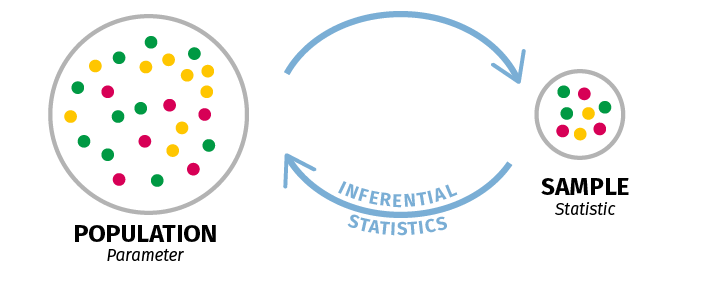

The **population** is the entire group or process that we want to understand. Characteristics of the population are called **parameters**. For example, the population may have a true mean $\mu$ and a true standard deviation $\sigma$.

Usually, we cannot observe the entire population. Instead, we collect a **sample** from the population and calculate **statistics** from that sample. Examples include the sample mean $\bar{x}$ and sample standard deviation $s$.

This gives us an important distinction:

- **Parameter:** a numerical characteristic of a population.
- **Statistic:** a numerical characteristic calculated from a sample.
- **Distribution:** describes the possible values of a variable and how likely those values are.

The goal of **inferential statistics** is to use the sample and its statistics to learn about the population, its parameters, and the distribution that may have generated our observations.

We can think about this process in two directions:

$$\text{Population and Distribution} \longrightarrow \text{Sample} \longrightarrow \text{Statistics}$$

If we know the population distribution and its parameters, we can describe what kinds of samples and statistics we would expect to observe.

**TipGreg Comment**

Vegas can guarentee they make money over a long period of time, because they know the population and parameters (cards and dice)

In practice, however, we usually face the problem in the opposite direction:

$$\text{Observed Data} \longrightarrow \text{Sample Statistics} \longrightarrow \text{Inference about the Population}$$

We observe data and calculate statistics, then use those observations to make conclusions about the population and its unknown parameters or distribution.

**TipGreg Comment**

So, **the sample is what we can see, while the population is what we are trying to understand**. We use statistics calculated from our sample to make inferences about the population that produced the data.

## 1. Statisics

Statistics is the study of learning from data while acknowledging variation and uncertainty. A dataset gives observed values from a sample. We use **descriptive statistics** to summarize those values and **inferential statistics** to reason from the sample to a larger population or process.

A single summary never tells the whole story. Here are categories:

- **Center:** Where are typical values located?
- **Spread:** How much do values vary?
- **Shape:** Is the distribution symmetric, skewed, flat, peaked, or heavy-tailed?

**TipGreg Comment**

Which statistics make sense to use? Explain what these are and why would you use them?

### Common summary statistics

| Summary | Meaning | Important limitation |
| --- | --- | --- |
| Mean | Arithmetic average; the balance point | Strongly affected by extreme values; may not exist |
| Median | The 50th percentile; half the probability is on each side | Does not describe tail size |
| Mode | Value with greatest probability or density | Can be non-unique; for continuous data it is not necessarily an observed value |
| Standard deviation | Typical distance from the mean, measured through squared deviations | Requires a finite mean and variance; strongly affected by extremes |
| Minimum and maximum | Smallest and largest values | Each depends on a single observation and is highly sensitive to extremes |
| Range | Maximum minus minimum; total observed spread | Highly sensitive to extremes and usually increases with sample size |
| Quantiles (percentiles) | Values below which specified proportions of the distribution fall | Individual quantiles provide limited information about the overall shape |
| Interquartile range (IQR) | Difference between the 75th and 25th percentiles; spread of the middle 50% | Does not describe the tails and ignores half the observations when measuring spread |
| Variance | Average squared distance from the mean | Expressed in squared units and strongly affected by extremes |
| Median absolute deviation (MAD) | Typical absolute distance from the median | Robust to extremes but less familiar; multiple scaling conventions are used |
| Skewness | Degree and direction of asymmetry | Can be unstable and strongly affected by extremes; one number cannot fully describe asymmetry |
| Kurtosis | Weight of the tails, often compared with the normal distribution | Frequently misinterpreted as “peakedness” and highly sensitive to extremes |
| Trimmed mean | Mean after removing a specified proportion from each tail | Depends on an arbitrary trimming percentage and discards some information |
| Geometric mean | Multiplicative average, useful for ratios and growth factors | Usually requires positive values and is inappropriate for additive quantities |
| Coefficient of variation | Standard deviation relative to the mean | Meaningful mainly for ratio-scale data with a positive, nonzero mean |

For a symmetric, single-peaked distribution such as the normal, mean, median, and mode coincide. For a right-skewed distribution, the long right tail usually pulls the mean above the median. A small standard deviation means values concentrate near the mean; a large one means they are more dispersed—but distributions with the same mean and SD can still have very different shapes.

**TipGreg Comment**

A distribution is a model for variation. It answers what values are possible and what process could have generated them?

### Discrete versus continuous

- **Discrete:** countable outcomes, such as 0/1, number of defects, or number of arrivals.
- **Continuous:** values on an interval, such as time, distance, or temperature.

**TipGreg Comment**

Are these discrete or continuous: number of emails, time until the next email, exam score, and whether a customer renews.

What about the gallery below?

What does all this code do? can you rewrite it?

### Distribution gallery

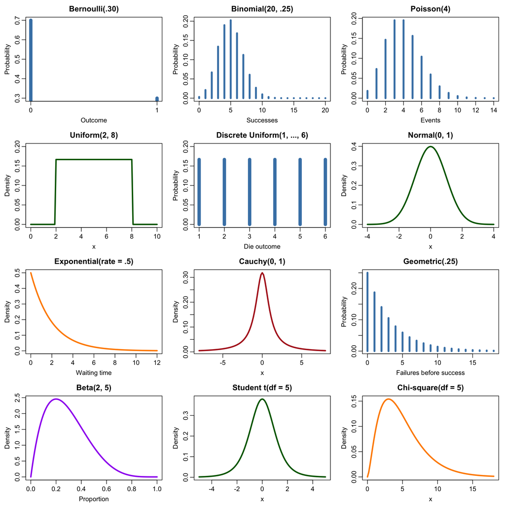

```r
old_par <- par(mfrow = c(4, 3), mar = c(3.2, 3.3, 2.2, 0.8),
               mgp = c(1.9, 0.6, 0), cex = 0.85)

plot(0:1, dbinom(0:1, 1, 0.30), type = "h", lwd = 7,
     xlab = "Outcome", ylab = "Probability", main = "Bernoulli(.30)",
     col = "steelblue", xaxt = "n")
axis(1, at = 0:1)
plot(0:20, dbinom(0:20, 20, 0.25), type = "h", lwd = 4,
     xlab = "Successes", ylab = "Probability", main = "Binomial(20, .25)",
     col = "steelblue")
plot(0:14, dpois(0:14, 4), type = "h", lwd = 4,
     xlab = "Events", ylab = "Probability", main = "Poisson(4)",
     col = "steelblue")
curve(dunif(x, 2, 8), 0, 10, ylim = c(0, 0.20), lwd = 3,
      xlab = "x", ylab = "Density", main = "Uniform(2, 8)", col = "darkgreen")
plot(1:6, rep(1 / 6, 6), type = "h", lwd = 7,
     xlab = "Die outcome", ylab = "Probability",
     main = "Discrete Uniform(1, ..., 6)",
     col = "steelblue", xaxt = "n",
     ylim = c(0, 0.20))
axis(1, at = 1:6)
points(1:6, rep(1 / 6, 6), pch = 16, col = "steelblue")
curve(dnorm(x), -4, 4, lwd = 3,
      xlab = "x", ylab = "Density", main = "Normal(0, 1)", col = "darkgreen")
curve(dexp(x, 0.5), 0, 12, lwd = 3,
      xlab = "Waiting time", ylab = "Density", main = "Exponential(rate = .5)",
      col = "darkorange")
curve(dcauchy(x), -8, 8, lwd = 3,
      xlab = "x", ylab = "Density", main = "Cauchy(0, 1)", col = "firebrick")
plot(0:18, dgeom(0:18, 0.25), type = "h", lwd = 4,
     xlab = "Failures before success", ylab = "Probability",
     main = "Geometric(.25)", col = "steelblue")
curve(dbeta(x, 2, 5), 0, 1, lwd = 3,
      xlab = "Proportion", ylab = "Density", main = "Beta(2, 5)", col = "purple")
curve(dt(x, 5), -5, 5, lwd = 3,
      xlab = "x", ylab = "Density", main = "Student t(df = 5)", col = "darkgreen")
curve(dchisq(x, 5), 0, 18, lwd = 3,
      xlab = "x", ylab = "Density", main = "Chi-square(df = 5)",
      col = "darkorange")
```

**TipGreg Comment**

Identify which distributions are discrete, symmetric, right/left-skewed, or heavy-tailed.

### Center and spread for the plotted examples

Compare graphs to the values in the table below. Values are population quantities, rounded to three decimals.

| Distribution shown | Typical story | Mean | Median | Mode | Standard deviation |
| --- | --- | --- | --- | --- | --- |
| Bernoulli($p=.30$) | One success/failure trial | 0.300 | 0 | 0 | 0.458 |
| Binomial($n=20,p=.25$) | Successes in 20 trials | 5.000 | 5 | 5 | 1.936 |
| Poisson($\lambda=4$) | Events per fixed exposure | 4.000 | 4 | 3 and 4 | 2.000 |
| Uniform(2, 8) | Any value in a bounded interval is equally dense | 5.000 | 5.000 | Every value in [2, 8] | 1.732 |
| Normal(0, 1) | Symmetric measurement variation | 0.000 | 0.000 | 0.000 | 1.000 |
| Exponential(rate = 0.5) | Waiting time until an event | 2.000 | 1.386 | 0.000 | 2.000 |
| Cauchy(location = 0, scale = 1) | Symmetric variation with extremely heavy tails | Undefined | 0.000 | 0.000 | Undefined |
| Geometric($p=.25$) | Failures before first success | 3.000 | 2 | 0 | 3.464 |
| Beta(2, 5) | A continuous proportion between 0 and 1 | 0.286 | 0.264 | 0.200 | 0.160 |
| Student’s $t(df=5)$ | Standardized mean with estimated SD | 0.000 | 0.000 | 0.000 | 1.291 |
| Chi-square($df=5$) | Sum of five squared standard normals | 5.000 | 4.351 | 3.000 | 3.162 |

### Shape spotlight: right-skewed, left-skewed, and bimodal

“Right-skewed,” “left-skewed,” and “bimodal” describe a distribution’s **shape**; they are not three unique distribution families. Many different models can have these shapes. The examples below use beta distributions for opposite directions of skew and a mixture of two normal distributions for bimodality.

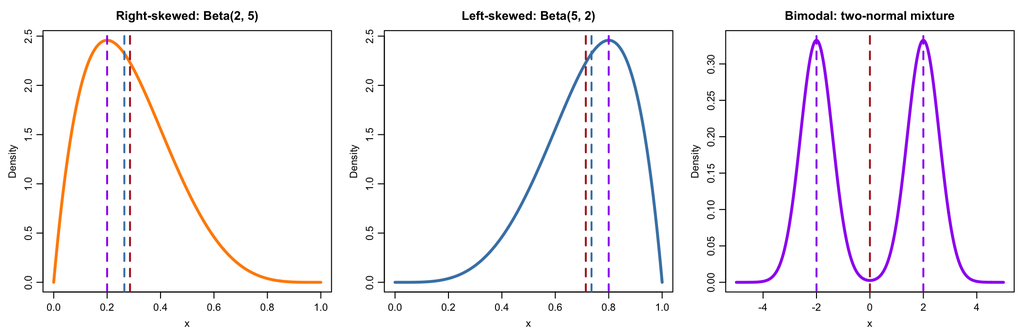

```r
x_beta <- seq(0, 1, length.out = 600)
x_mix <- seq(-5, 5, length.out = 800)
mix_density <- 0.5 * dnorm(x_mix, mean = -2, sd = 0.6) +
               0.5 * dnorm(x_mix, mean =  2, sd = 0.6)

old_par <- par(mfrow = c(1, 3), mar = c(3.5, 3.5, 2.5, 0.8),
               mgp = c(2, 0.7, 0))

plot(x_beta, dbeta(x_beta, 2, 5), type = "l", lwd = 3,
     col = "darkorange", xlab = "x", ylab = "Density",
     main = "Right-skewed: Beta(2, 5)")
abline(v = c(0.20, qbeta(0.5, 2, 5), 2/7),
       col = c("purple", "steelblue", "firebrick"), lty = 2, lwd = 2)

plot(x_beta, dbeta(x_beta, 5, 2), type = "l", lwd = 3,
     col = "steelblue", xlab = "x", ylab = "Density",
     main = "Left-skewed: Beta(5, 2)")
abline(v = c(0.80, qbeta(0.5, 5, 2), 5/7),
       col = c("purple", "steelblue", "firebrick"), lty = 2, lwd = 2)

plot(x_mix, mix_density, type = "l", lwd = 3,
     col = "purple", xlab = "x", ylab = "Density",
     main = "Bimodal: two-normal mixture")
abline(v = c(-2, 0, 2),
       col = c("purple", "firebrick", "purple"), lty = 2, lwd = 2)
```

```r
par(old_par)
```

In the beta plots, purple marks the mode, blue the median, and red the mean. Notice the ordering:

- Right-skewed: mode < median < mean. The long right tail pulls the mean upward.
- Left-skewed: mean < median < mode. The long left tail pulls the mean downward.
- Bimodal: the mixture has two peaks. Its mean and median are both zero, even though zero is a low-density valley and is not a typical observation.

| Shape example | Mean | Median | Mode | Standard deviation |
| --- | --- | --- | --- | --- |
| Right-skewed Beta(2, 5) | 0.286 | 0.264 | 0.200 | 0.160 |
| Left-skewed Beta(5, 2) | 0.714 | 0.736 | 0.800 | 0.160 |
| Equal mixture: $N(-2,0.6^2)$ and $N(2,0.6^2)$ | 0.000 | 0.000 | Approximately -2 and 2 | 2.088 |

**TipGreg Comment**

Jump to keynote for 167A review

## 2. R’s distribution-function grammar

For most named distributions, R uses the same four prefixes:

| Prefix | Meaning | Typical question |
| --- | --- | --- |
| `d` | Density or probability mass | How plausible is this value? |
| `p` | Cumulative probability | What is $P(X ≤ x)$? |
| `q` | Quantile | What cutoff has a given cumulative probability? |
| `r` | Random generation | What would simulated observations look like? |

**TipGreg Comment**

Try different options in R

```r
# For X ~ Binomial(size = 10, prob = 0.30)
dbinom(4, size = 10, prob = 0.30)       # P(X = 4)
```

```
[1] 0.2001209
```

```r
dbinom(0:4, size = 10, prob = 0.30)
```

```
[1] 0.02824752 0.12106082 0.23347444 0.26682793 0.20012095
```

```r
dbinom(0:4, size = 10, prob = 0.30) |> sum()
```

```
[1] 0.8497317
```

```r
pbinom(4, size = 10, prob = 0.30)       # P(X <= 4)
```

```
[1] 0.8497317
```

```r
qbinom(0.95, size = 10, prob = 0.30)    # 95th percentile
```

```
[1] 5
```

```r
dbinom(0:5, size = 10, prob = 0.30) |> sum()
```

```
[1] 0.952651
```

```r
rbinom(100, size = 10, prob = 0.30)       # 100 simulated values
```

```
  [1] 2 2 2 2 1 2 5 3 2 5 3 3 5 1 3 2 1 3 3 3 1 0 0 2 1 1 2 1 4 4 2 4 3 3 3 1 3
 [38] 2 3 2 2 4 5 3 4 2 3 4 3 2 3 3 4 3 4 7 2 1 6 2 2 2 4 2 1 5 3 1 3 3 1 4 2 4
 [75] 5 1 2 5 3 4 3 4 1 3 3 2 2 4 3 3 4 2 5 2 2 4 5 2 5 2
```

```r
rbinom(100, size = 10, prob = 0.30) |> mean()
```

```
[1] 3.03
```

**Teaching warning:** for a continuous variable, `dnorm(2)` is a density height, not $P(X=2)$. The probability at any exact point is zero; probabilities are areas over intervals.

## 3. Discrete distributions

### Bernoulli: one binary trial

Use when one trial has two outcomes, coded 1 and 0.

$$X \sim \operatorname{Bernoulli}(p), \qquad E(X)=p, \qquad \operatorname{Var}(X)=p(1-p).$$

R treats a Bernoulli variable as a binomial variable with `size = 1`.

```r
set.seed(2026)
x <- rbinom(1000, size = 1, prob = 0.30)
mean(x)                    # simulated proportion of successes
```

```
[1] 0.302
```

```r
var(x)
```

```
[1] 0.211007
```

```r
c(theory_mean = 0.30,
  theory_variance = 0.30 * 0.70)
```

```
    theory_mean theory_variance
           0.30            0.21
```

**Prompt:** Why does the sample mean of 0/1 observations equal the sample proportion?

### Binomial: successes in a fixed number of trials

Use for the number of successes in $n$ trials when:

- the number of trials is fixed;
- trials are independent;
- each trial is binary; and
- the success probability $p$ is constant.

$$X \sim \operatorname{Binomial}(n,p), \qquad E(X)=np, \qquad \operatorname{Var}(X)=np(1-p).$$

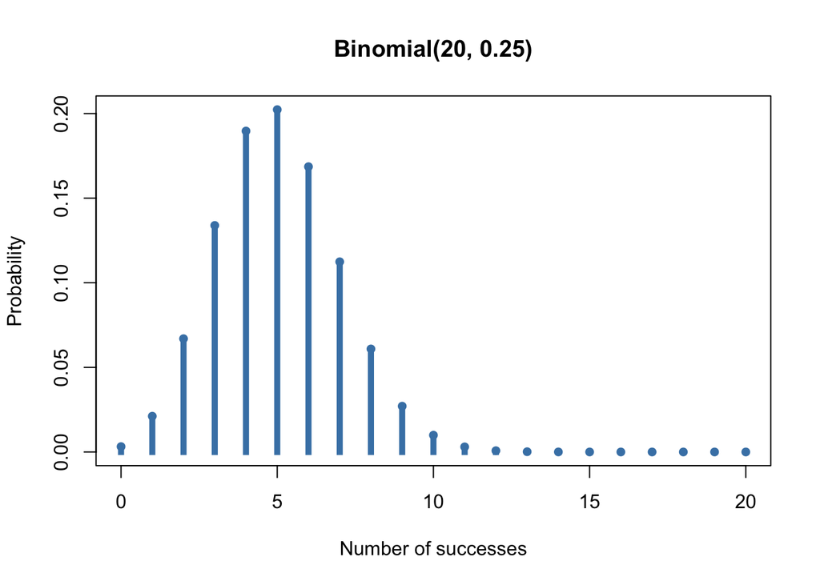

```r
n <- 20
p <- 0.25
k <- 0:n
prob <- dbinom(k, size = n, prob = p)

plot(k, prob, type = "h", lwd = 5, lend = 2,
     xlab = "Number of successes", ylab = "Probability",
     main = "Binomial(20, 0.25)", col = "steelblue")
points(k, prob, pch = 16, col = "steelblue")
```

```r
# Exactly 7 successes and at least 7 successes
dbinom(7, size = n, prob = p)
```

```
[1] 0.1124062
```

```r
1 - pbinom(6, size = n, prob = p)
```

```
[1] 0.2142181
```

**Pair task:** Compute $P(X \ge 7)$, then estimate it from 100,000 simulations. Explain any discrepancy.

```r
set.seed(2026)
sim_binom <- rbinom(100000, size = n, prob = p)
mean(sim_binom >= 7)
```

```
[1] 0.21686
```

### Poisson: event counts over exposure

Use for counts in a fixed interval of time, space, area, or other exposure when events occur independently at a stable average rate.

$$X \sim \operatorname{Poisson}(\lambda), \qquad E(X)=\operatorname{Var}(X)=\lambda.$$

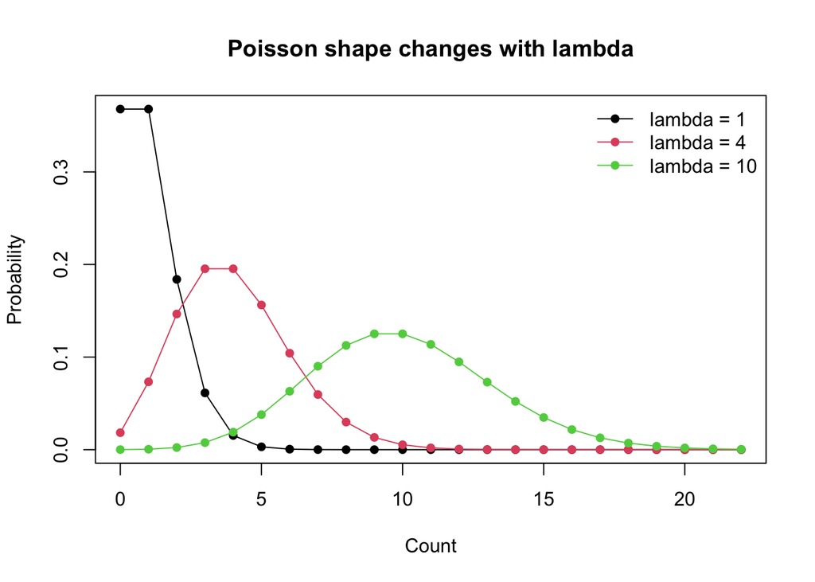

```r
lambda_values <- c(1, 4, 10)
k <- 0:22

matplot(k,
        sapply(lambda_values, function(z) dpois(k, lambda = z)),
        type = "o", pch = 16, lty = 1,
        xlab = "Count", ylab = "Probability",
        main = "Poisson shape changes with lambda")
legend("topright", legend = paste("lambda =", lambda_values),
       col = 1:3, lty = 1, pch = 16, bty = "n")
```

**Think–pair–share:** A help desk averages 4 calls per hour. Under a Poisson model, what is the probability of more than 6 calls next hour?

```r
1 - ppois(6, lambda = 4)
```

```
[1] 0.110674
```

Discuss the assumption hidden in “averages 4”: a mean rate alone does not guarantee a Poisson process. Clustering, changing rates, or dependence can break the model. A quick empirical warning sign is variance far larger than the mean.

## 4. Continuous distributions

### Uniform: equal density across an interval

Use when values within $[a,b]$ have equal density.

$$X \sim \operatorname{Uniform}(a,b), \qquad
E(X)=\frac{a+b}{2}, \qquad
\operatorname{Var}(X)=\frac{(b-a)^2}{12}.$$

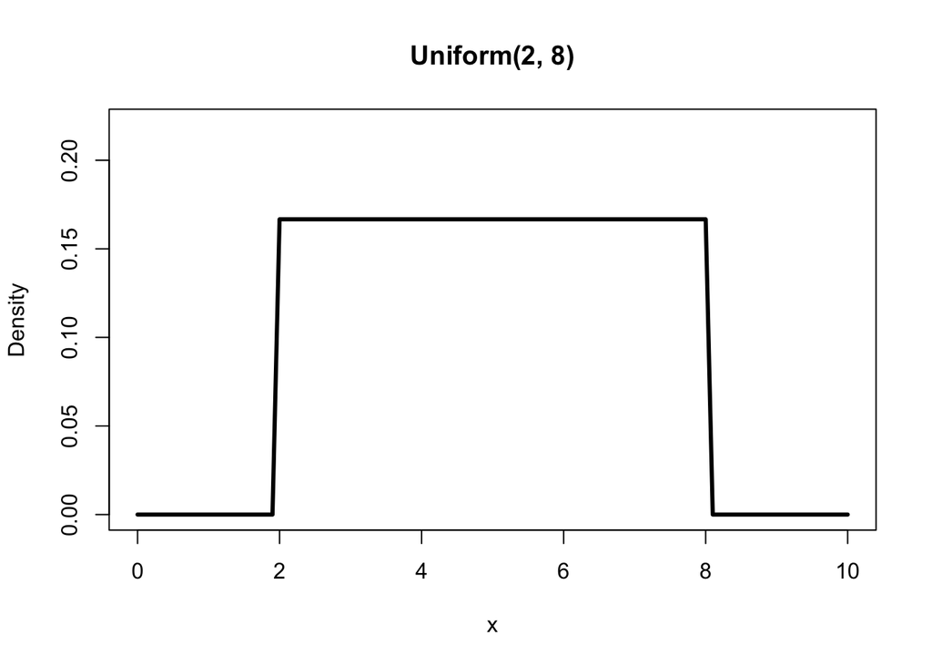

```r
curve(dunif(x, min = 2, max = 8), from = 0, to = 10,
      ylim = c(0, 0.22), lwd = 3,
      xlab = "x", ylab = "Density",
      main = "Uniform(2, 8)")
```

```r
# P(3 <= X <= 5)
punif(5, min = 2, max = 8) - punif(3, min = 2, max = 8)
```

```
[1] 0.3333333
```

**Prompt:** If equal-width intervals have equal probability, why is the density $1/(b-a)$ instead of 1?

### Normal: symmetric variation around a center

The normal distribution is controlled by its mean $\mu$ and standard deviation $\sigma$:

$$X \sim N(\mu,\sigma^2).$$

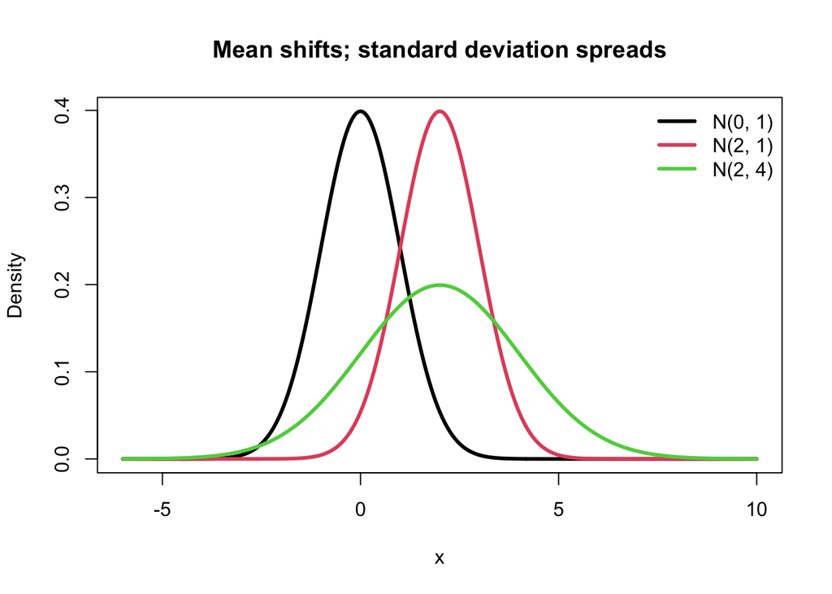

```r
x <- seq(-6, 10, length.out = 600)
curves <- cbind(
  dnorm(x, mean = 0, sd = 1),
  dnorm(x, mean = 2, sd = 1),
  dnorm(x, mean = 2, sd = 2)
)
matplot(x, curves, type = "l", lwd = 3, lty = 1,
        xlab = "x", ylab = "Density",
        main = "Mean shifts; standard deviation spreads")
legend("topright",
       legend = c("N(0, 1)", "N(2, 1)", "N(2, 4)"),
       col = 1:3, lty = 1, lwd = 3, bty = "n")
```

```r
# Central 95% interval for a standard normal variable
qnorm(c(0.025, 0.975))
```

```
[1] -1.959964  1.959964
```

**Important distinction:** approximately normal data and a normal sampling distribution are different claims. The CLT concerns the latter.

### Exponential: waiting time to the next event

In a Poisson process with rate $\lambda$, the count in an interval is Poisson and the waiting time until the next event is exponential.

$$X \sim \operatorname{Exponential}(\lambda), \qquad
E(X)=\frac{1}{\lambda}, \qquad
\operatorname{Var}(X)=\frac{1}{\lambda^2}.$$

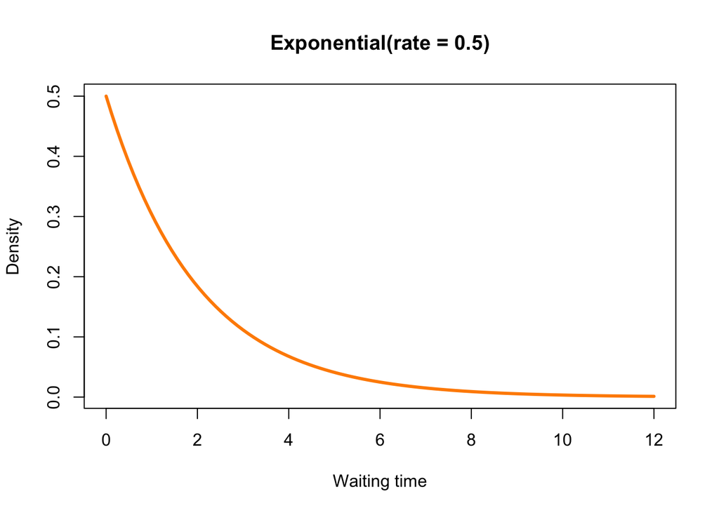

```r
curve(dexp(x, rate = 0.5), from = 0, to = 12,
      lwd = 3, col = "darkorange",
      xlab = "Waiting time", ylab = "Density",
      main = "Exponential(rate = 0.5)")
```

```r
# Probability the wait exceeds 5 units
pexp(5, rate = 0.5, lower.tail = FALSE)
```

```
[1] 0.082085
```

The exponential distribution is memoryless:

$$P(X>s+t\mid X>s)=P(X>t).$$

**Simulation check:** compare the probability of waiting at least 3 more minutes after already waiting 5 minutes with the probability of a fresh wait exceeding 3 minutes.

```r
set.seed(2026)
waits <- rexp(1000000, rate = 0.5)
mean(waits > 8) / mean(waits > 5)
```

```
[1] 0.2237841
```

```r
mean(waits > 3)
```

```
[1] 0.22262
```

### Cauchy: symmetric, bell-shaped, and extremely heavy-tailed

The Cauchy distribution is useful precisely because it challenges normal-distribution intuition. It is symmetric and bell-shaped, but its tails are so heavy that its population mean and variance do not exist.

$$X \sim \operatorname{Cauchy}(x_0,\gamma), \qquad
f(x)=\frac{1}{\pi\gamma\left[1+\left(\frac{x-x_0}{\gamma}\right)^2\right]}.$$

Here $x_0$ is the location (and median), and $\gamma>0$ is the scale. Neither parameter is a mean or standard deviation.

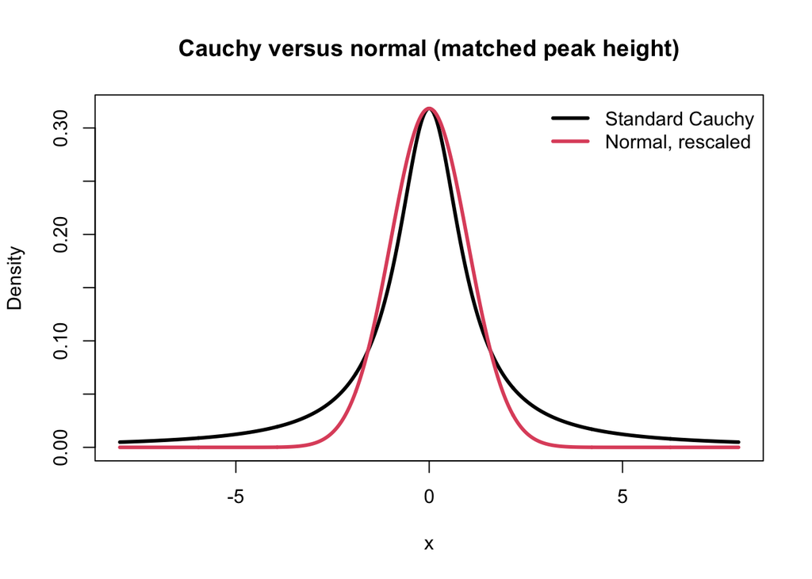

```r
x <- seq(-8, 8, length.out = 1000)
normal_scaled <- dnorm(x) * dcauchy(0) / dnorm(0)

matplot(x, cbind(dcauchy(x), normal_scaled),
        type = "l", lwd = 3, lty = 1,
        xlab = "x", ylab = "Density",
        main = "Cauchy versus normal (matched peak height)")
legend("topright", c("Standard Cauchy", "Normal, rescaled"),
       col = 1:2, lty = 1, lwd = 3, bty = "n")
```

```r
# Tail comparison: P(|X| > cutoff)
cutoffs <- c(2, 5, 10)
cbind(
  cutoff = cutoffs,
  Cauchy = 2 * pcauchy(-cutoffs),
  Normal = 2 * pnorm(-cutoffs)
)
```

```
     cutoff     Cauchy       Normal
[1,]      2 0.29516724 4.550026e-02
[2,]      5 0.12566592 5.733031e-07
[3,]     10 0.06345103 1.523971e-23
```

The sample median is meaningful for Cauchy data, but the sample mean is unstable. A single extreme observation can move it dramatically.

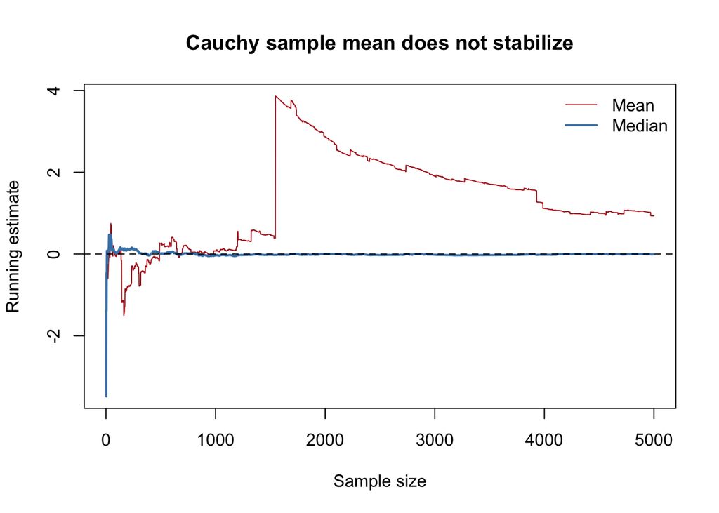

```r
set.seed(2026)
x_cauchy <- rcauchy(5000)
running_mean <- cumsum(x_cauchy) / seq_along(x_cauchy)
running_median <- sapply(seq_along(x_cauchy), function(i) median(x_cauchy[1:i]))

plot(running_mean, type = "l", col = "firebrick",
     xlab = "Sample size", ylab = "Running estimate",
     main = "Cauchy sample mean does not stabilize")
lines(running_median, col = "steelblue", lwd = 2)
abline(h = 0, lty = 2)
legend("topright", c("Mean", "Median"),
       col = c("firebrick", "steelblue"), lty = 1,
       lwd = c(1, 2), bty = "n")
```

**Prompts:**

1. How can a symmetric distribution fail to have a mean of zero?
2. Why are the location and scale parameters not the mean and standard deviation?
3. Which estimator—mean or median—would you trust more for Cauchy data, and why?

The Cauchy distribution also arises as the ratio of two independent standard normal variables. Students can verify this by simulation:

```r
set.seed(2026)
ratio <- rnorm(100000) / rnorm(100000)
quantile(ratio, c(0.10, 0.25, 0.50, 0.75, 0.90))
```

```
         10%          25%          50%          75%          90%
-3.097133735 -1.003946079 -0.006216914  1.016618542  3.091525463
```

```r
qcauchy(c(0.10, 0.25, 0.50, 0.75, 0.90))
```

```
[1] -3.077684 -1.000000  0.000000  1.000000  3.077684
```

## 5. Distributions that appear in inference

### Student’s t: normal-like, with heavier tails

The $t$ distribution arises when standardizing a sample mean while estimating the population standard deviation. Its degrees of freedom control tail weight. As degrees of freedom increase, it approaches the standard normal distribution.

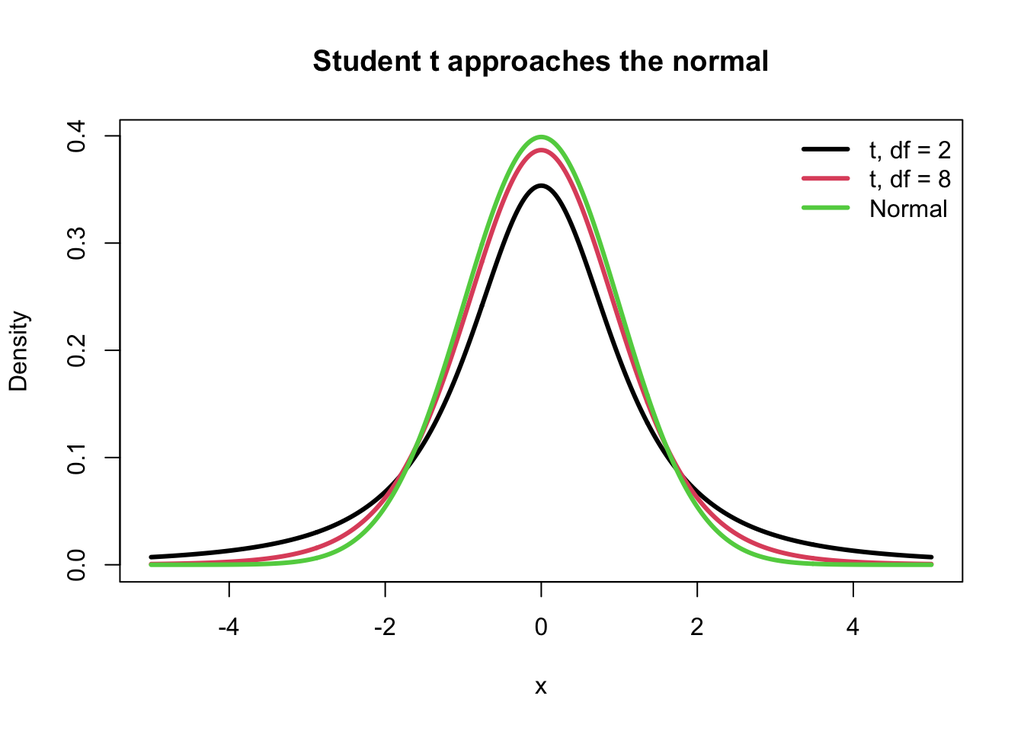

```r
x <- seq(-5, 5, length.out = 600)
y <- cbind(dt(x, df = 2), dt(x, df = 8), dnorm(x))
matplot(x, y, type = "l", lwd = 3, lty = 1,
        xlab = "x", ylab = "Density",
        main = "Student t approaches the normal")
legend("topright", legend = c("t, df = 2", "t, df = 8", "Normal"),
       col = 1:3, lty = 1, lwd = 3, bty = "n")
```

```r
qt(0.975, df = c(2, 8, 30, 1000))
```

```
[1] 4.302653 2.306004 2.042272 1.962339
```

**Prompt:** How do heavier tails change a confidence interval compared with using the normal critical value?

### Chi-square: positive and right-skewed

If $Z_1,\ldots,Z_k$ are independent standard normal variables, then $\sum Z_i^2$ has a chi-square distribution with $k$ degrees of freedom. It appears in inference for variances and in contingency-table procedures.

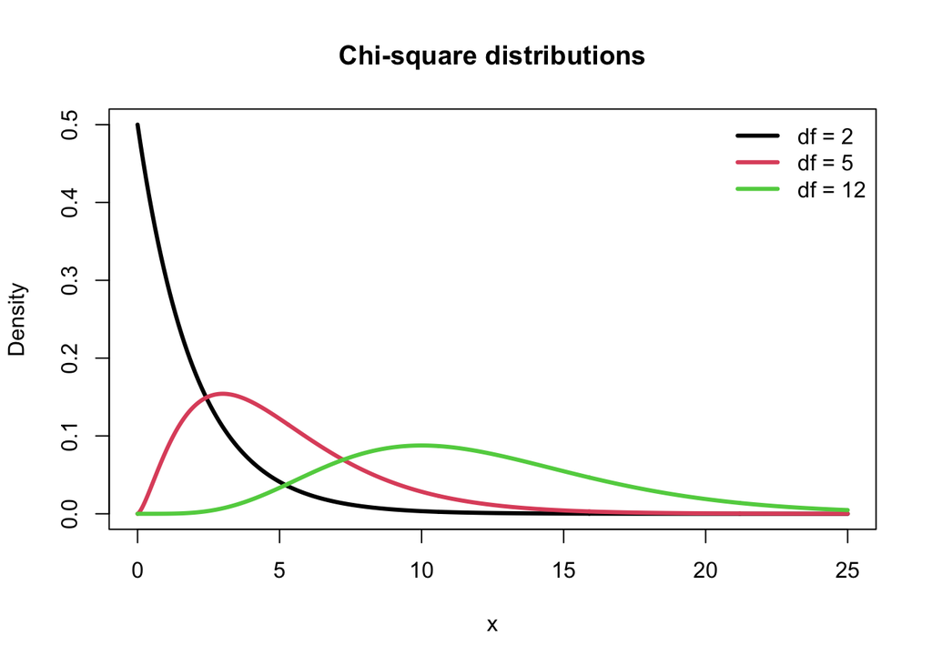

```r
x <- seq(0, 25, length.out = 600)
y <- cbind(dchisq(x, df = 2), dchisq(x, df = 5), dchisq(x, df = 12))
matplot(x, y, type = "l", lwd = 3, lty = 1,
        xlab = "x", ylab = "Density",
        main = "Chi-square distributions")
legend("topright", legend = c("df = 2", "df = 5", "df = 12"),
       col = 1:3, lty = 1, lwd = 3, bty = "n")
```

## 6. Central Limit Theorem: distributions of sample means

### The central idea

Let $X_1,\ldots,X_n$ be independent and identically distributed observations with finite population mean $\mu$ and finite population variance $\sigma^2$. As $n$ grows, the standardized sample mean

$$\frac{\bar X-\mu}{\sigma/\sqrt{n}}$$

approaches a standard normal distribution. Equivalently, for sufficiently large $n$,

$$\bar X \approx N\left(\mu,\frac{\sigma^2}{n}\right).$$

This says:

- the center of the sampling distribution is $\mu$;
- its standard error is $\sigma/\sqrt{n}$; and
- its shape becomes approximately normal under the theorem’s conditions.

It does **not** say:

- the original population becomes normal;
- every statistic is approximately normal;
- $n=30$ is a universal threshold; or
- large samples repair dependence, severe selection bias, or infinite variance.

### Simulation function

Each simulated mean below represents a new random sample—think “repeat the whole study,” not “resample one observation.”

```r
simulate_means <- function(generator, n, reps = 10000) {
  replicate(reps, mean(generator(n)))
}

plot_sampling_distributions <- function(generator, n_values, pop_mean,
                                        pop_sd, label) {
  old_par <- par(mfrow = c(1, length(n_values)))
  on.exit(par(old_par))

  for (n in n_values) {
    means <- simulate_means(generator, n)
    hist(means, probability = TRUE, breaks = 35,
         col = "gray85", border = "white",
         main = paste(label, "\nn =", n), xlab = "Sample mean")
    curve(dnorm(x, mean = pop_mean, sd = pop_sd / sqrt(n)),
          add = TRUE, col = "firebrick", lwd = 3)
  }
}
```

### Parent population A: exponential (strong right skew)

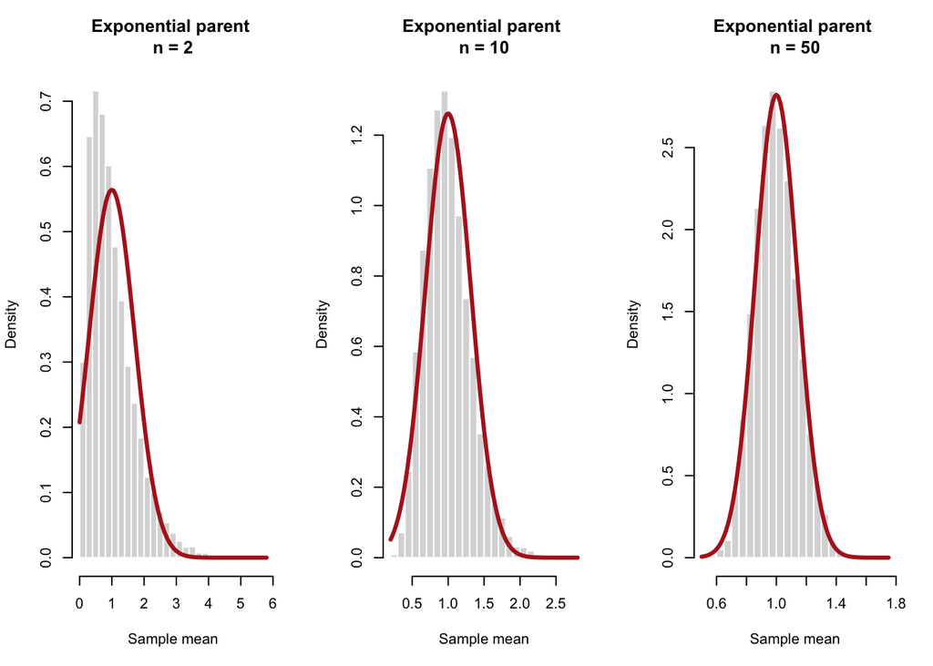

```r
set.seed(2026)
plot_sampling_distributions(
  generator = function(n) rexp(n, rate = 1),
  n_values = c(2, 10, 50),
  pop_mean = 1,
  pop_sd = 1,
  label = "Exponential parent"
)
```

Ask students:

1. What stays fixed as $n$ grows?
2. What changes?
3. Is the red curve describing the individual observations or the sample means?

### Parent population B: Bernoulli (discrete and asymmetric)

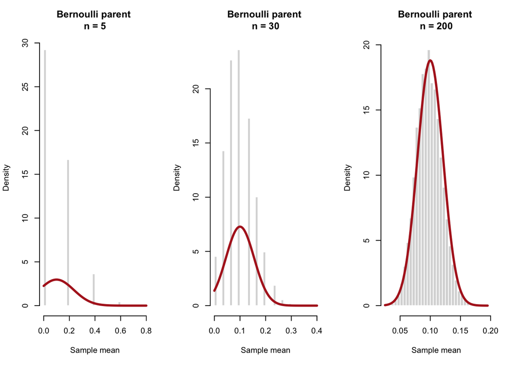

```r
set.seed(2026)
p <- 0.10
plot_sampling_distributions(
  generator = function(n) rbinom(n, size = 1, prob = p),
  n_values = c(5, 30, 200),
  pop_mean = p,
  pop_sd = sqrt(p * (1 - p)),
  label = "Bernoulli parent"
)
```

The small-$n$ sampling distribution is visibly discrete. With rare outcomes, normal approximation may require a much larger $n$ than a symmetric parent population would.

### Quantifying the standard-error claim

```r
set.seed(2026)
n_values <- c(2, 5, 10, 25, 50, 100)

results <- do.call(rbind, lapply(n_values, function(n) {
  means <- simulate_means(function(m) rexp(m, rate = 1), n, reps = 20000)
  data.frame(
    n = n,
    simulated_mean = mean(means),
    theoretical_mean = 1,
    simulated_sd = sd(means),
    theoretical_se = 1 / sqrt(n)
  )
}))

round(results, 4)
```

```
    n simulated_mean theoretical_mean simulated_sd theoretical_se
1   2         0.9990                1       0.7062         0.7071
2   5         0.9965                1       0.4470         0.4472
3  10         0.9975                1       0.3154         0.3162
4  25         0.9980                1       0.2018         0.2000
5  50         1.0008                1       0.1410         0.1414
6 100         1.0015                1       0.1008         0.1000
```

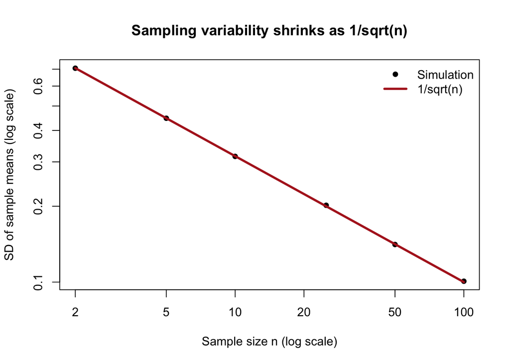

```r
plot(results$n, results$simulated_sd, log = "xy", pch = 16,
     xlab = "Sample size n (log scale)",
     ylab = "SD of sample means (log scale)",
     main = "Sampling variability shrinks as 1/sqrt(n)")
lines(results$n, results$theoretical_se, col = "firebrick", lwd = 3)
legend("topright", c("Simulation", "1/sqrt(n)"),
       pch = c(16, NA), lty = c(NA, 1), col = c(1, "firebrick"),
       lwd = c(NA, 3), bty = "n")
```

**Key tradeoff:** to cut the standard error in half, multiply the sample size by four.

### CLT challenge: a case where the usual version fails

The Cauchy distribution has no finite mean or variance, so the usual CLT conditions do not hold. Averages of Cauchy observations do not settle down like normal sample means.

```r
set.seed(2026)
cauchy_small <- simulate_means(rcauchy, n = 5, reps = 10000)
cauchy_large <- simulate_means(rcauchy, n = 500, reps = 10000)

quantile(cauchy_small, c(0.10, 0.25, 0.50, 0.75, 0.90))
```

```
        10%         25%         50%         75%         90%
-3.12130533 -1.00177963  0.01117624  0.98401194  3.01638011
```

```r
quantile(cauchy_large, c(0.10, 0.25, 0.50, 0.75, 0.90))
```

```
        10%         25%         50%         75%         90%
-3.02216467 -0.97877363  0.01991343  1.03143096  3.10021269
```

**Discussion:** Why is “the sample size is large” not, by itself, a complete CLT justification?

## 7. Choosing a distribution from the story

| Data-generating story | Candidate distribution | First assumptions to question |
| --- | --- | --- |
| One yes/no outcome | Bernoulli | Is the outcome genuinely binary? |
| Successes in fixed $n$ trials | Binomial | Independence and constant $p$ |
| Event count per exposure | Poisson | Stable rate, independence, mean ≈ variance |
| Equal density on a bounded interval | Uniform | Is equal plausibility defensible? |
| Symmetric continuous measurement | Normal | Skew, outliers, bounds, mixtures |
| Waiting time in a Poisson process | Exponential | Constant hazard and memorylessness |
| Symmetric data with very heavy tails | Cauchy | Mean and variance do not exist; extremes dominate |
| Standardized mean with estimated SD | Student’s $t$ | Sampling design and model conditions |
| Sum of squared standard normals | Chi-square | Independence and normal-based derivation |

Emphasize that this table proposes candidates, not automatic answers. Context, diagnostics, and the intended analysis still matter.

## 8. Exit ticket

Have each student answer in two or three sentences:

1. A website records the number of purchases per customer in a month. Which distribution might you try first, and what feature of the data could make you reject it?
2. State the CLT in terms of the distribution of a statistic—not the distribution of raw observations.
3. In R, which function would find the 99th percentile of a $t$ distribution with 12 degrees of freedom? Write the call.

Suggested answers:

1. Poisson is a possible starting point; overdispersion, excess zeros, dependence, or unequal exposure could make it unsuitable.
2. Under appropriate conditions, the standardized sample mean approaches a normal distribution as sample size grows; its standard error is $\sigma/\sqrt{n}$.
3. `qt(0.99, df = 12)`.

## Optional homework

Choose a distribution not covered in depth (for example, beta, gamma, geometric, or negative binomial). Submit:

- a data-generating story;
- its support and parameters;
- one density or probability-mass plot;
- one calculation using `p*` or `q*`; and
- a simulation showing how a parameter changes its shape.